# Tối ưu và giải hệ phương trình phi tuyến

# Optimization 1 chiều với R

## Bài tập trên lớp

*Tìm cực trị của hàm số $f\left(x\right)=\dfrac{ln(x)}{1+x}$.*

### Phương pháp Bisection

*Thuật thoán Bisection:*
*Bước 1:* Bắt đầu với khoảng $[a_0;b_0]$ sao cho $f'(a_0)f'(b_0)\le 0$, xác định:
$$x_0=\dfrac{a+b}{2}$$
*Bước 2:* Cập nhật khoảng nghiệm $[a_1;b_1]$ bởi:
$$\left[ a_{1};b_{1} \right]=
\begin{cases}[a_{0};x_{0}]&f^{\prime}(a_{0})f^{\prime}(x_{0})\leqslant
0,\\
[x_{0};b_{0}]&f^{\prime}(a_{0})f^{\prime}(x_{0})>0\end{cases}$$
và cập nhật $x_1=\dfrac{a_1+b_1}{2}$
*Bước 3:* Lập lại **bước 2** trong $M$ lần, khi đó với $t=1,...,M$
$$\left[ a_{t+1};b_{t+1} \right]=
\begin{cases}[a_{t};x_{t}]&f^{\prime}(a_{t})f^{\prime}(x_{t})\leqslant
0,\\
[x_{t};b_{t}]&f^{\prime}(a_{t})f^{\prime}(x_{t})>0\end{cases}$$
và
$$x_{t+1}=\dfrac{a_t+b_t}{2}.$$
*Code R:*
Định nghĩa hàm $f(x)=\dfrac{ln(x)}{1+x}$ trong R:

```r
fx <- function(x){
  (log(x)) / (1+x)
}
```

Vẽ đồ thị hàm số $f(x)$:

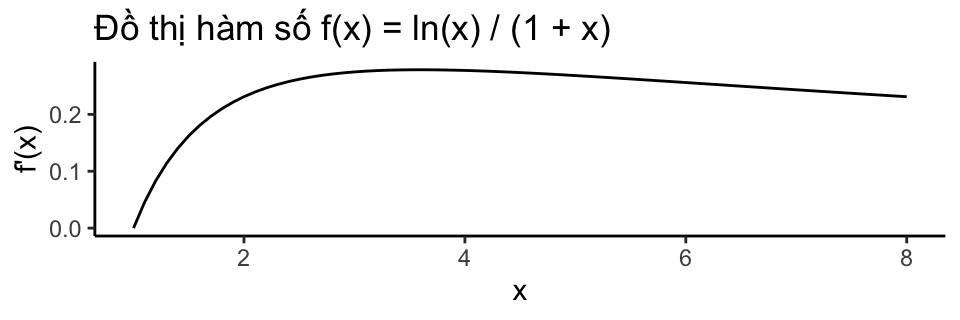

```r
x <- seq( 1 , 8, by = 0.1)
y <- fx(x)
# Vẽ đồ thị
ggplot(data.frame(x, y), aes(x = x, y = y)) +
  geom_line() +
  labs(x = "x", y = "f'(x)", title = "Đồ thị hàm số f(x) = ln(x) / (1 + x)") +
  theme_classic()
```

Đạo hàm cấp 1 của hàm số $f(x)$ là:
$$f'(x)=\dfrac{1+1/x-ln(x)}{(1+x)^2}$$
Định nghĩa đạo hàm cấp 1 trong R

```r
derivative1_f <- function(x){
  res <- (1 + (1/x) -(log(x)))/((1+x)^2)
  return(res)
}
```

Vẽ đồ thị $f'(x)$:

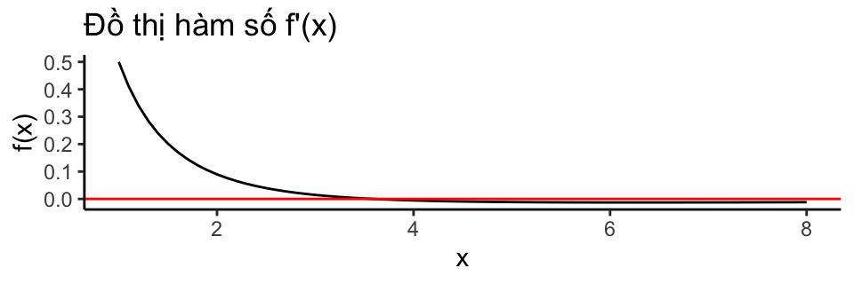

```r
x <- seq( 1 , 8, by = 0.1)
y1 <- derivative1_f(x)
# Vẽ đồ thị
ggplot(data.frame(x, y), aes(x = x, y = y1)) +
  geom_line() + geom_hline(yintercept = 0, color = "red") +
  labs(x = "x", y = "f(x)", title = "Đồ thị hàm số f'(x)") +
  theme_classic()
```

Kiểm tra $f'(1)\times f'(6)\le 0$:

```r
derivative1_f(1) * derivative1_f(6)
```

```
## [1] -0.006378498
```

Gán $a_0=1$ và $b_0=6$, sử dụng thuật toán Bisection chạy vòng lặp với $M=40$:

```r
a0 <- 1
b0 <- 6

x0 <- (a0+b0)/2

#vong lap
iter <- 40
for(i in 1:40){
  cond <- derivative1_f(a0) * derivative1_f(x0)
  if (cond > 0) {
    a0 <- x0
  } else {
    b0 <- x0
  }
  x0 <- (a0 + b0)/2
  print(x0)
}
```

```
## [1] 4.75
## [1] 4.125
## [1] 3.8125
## [1] 3.65625
## [1] 3.578125
## [1] 3.617188
## [1] 3.597656
## [1] 3.587891
## [1] 3.592773
## [1] 3.590332
## [1] 3.591553
## [1] 3.590942
## [1] 3.591248
## [1] 3.591095
## [1] 3.591171
```

[output cut: 25 more lines]

Trong thực tế, ta không thể lặp với số $M$ lớn. Ta cần tiêu chuẩn để dừng thuật toán.
*Tiêu chuẩn hội tụ tuyệt đối*:
$$t>log_2\left(\dfrac{b_0-a_0}{\delta}\right)-1$$
Ví dụ sai số $10^{-6}$ thì ta cần lặp:

```r
t <- log2((6-1)/(10)^(-6))-1
print(t)
```

```
## [1] 21.2535
```

*Cần lặp 22 lần.*  
*Tiêu chuẩn hội tụ tương đối*: *lí thuyết trong đề cương*

### Phương pháp Newton

*Thuật toán Newton*  
*Điều kiện:*

- $f''(x) \ne 0$ trên $[a;b]$.
- $f''(x)$ không đổi dấu trên $[a,b]$.
- $f'(a)f'(b)<0$.
- $|\dfrac{f'(a)}{f''(a)}|<b-a$ và $|\dfrac{f'(b)}{f''(b)}|<b-a$

Khi đó với mọi $x \in [a;b]$ thì $x$ sẽ hội tụ về cực trị của hàm số $f$ trên đoạn $[a;b]$.

Ta có công thức lặp nghiệm:
$$x_{t+1}=x_t-\dfrac{f'(x_t)}{f''(x_t)}$$

*Code R:*

Đạo hàm cấp hai của hàm $f$ là:
$$f''=-\dfrac{3+1/x^2+4/x-2ln(x)}{(1+x)^3}$$
Định nghĩa đạo hàm cấp 2 của hàm $f$ trong R:

```r
derivative2_f <- function(x){
  res <- (-(3+(1/(x^2))+4/x-2*log(x))/((1+x)^3))
  return(res)
}
```

Vẽ đồ thị $f'(x)$:

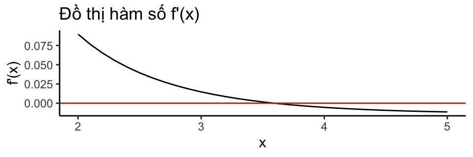

```r
x <- seq( 2 , 5, by = 0.1)
y2 <- derivative1_f(x)
# Vẽ đồ thị
ggplot(data.frame(x, y2), aes(x = x, y = y2)) +
  geom_line() + geom_hline(yintercept = 0, color = "red") +
  labs(x = "x", y = "f'(x)", title = "Đồ thị hàm số f'(x)") +
  theme_classic()
```

Vẽ đồ thị $f''(x)$:

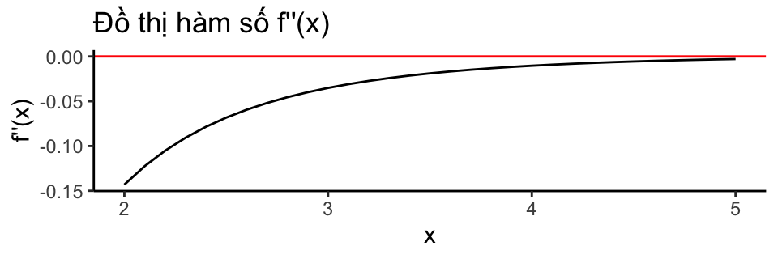

```r
x <- seq( 2 , 5, by = 0.1)
y3 <- derivative2_f(x)
# Vẽ đồ thị
ggplot(data.frame(x, y3), aes(x = x, y = y3)) +
  geom_line() + geom_hline(yintercept = 0, color = "red") +
  labs(x = "x", y = "f''(x)", title = "Đồ thị hàm số f''(x)") +
  theme_classic()
```

Đặt $h(x)=\dfrac{f'(x)}{f''(x)}$. Định nghĩa hàm $h(x)$ trên R.

```r
hx <- function(x){
  res <- derivative1_f(x) / derivative2_f(x)
  return(res)
}
```

Ta dễ dàng kiểm tra được đoạn $[2;4]$ thoả các điều kiện để sử dụng *phương pháp Newton* Chọn $x_0 = 3 \in [2;4]$.

Ta có công thức lặp nghiệm:
$$x_{t+1}=x_t-\dfrac{f'(x_t)}{f''(x_t)}$$

Chạy vòng lặp tìm cực trị:

```r
cauchy <- 3
#vong lap
for(i in 1:7){
  cauchy <- cauchy - hx(cauchy)
  print(cauchy, digits = 10)
}
```

```
## [1] 3.417798095
## [1] 3.574045197
## [1] 3.590946124
## [1] 3.591121458
## [1] 3.591121477
## [1] 3.591121477
## [1] 3.591121477
```

### Phương pháp Fisher Scoring

Phương pháp **Fisher Scoring** là một biến thể của phương pháp **Newton** (xem trong file bài giảng)

### Phương pháp Secant

Sử dụng công thức lặp nghiệm của phương pháp **Newton**, tuy nhiên đối với các công thức khó xác định đạo hàm cấp 2 một cách tường minh.

Ta thay $f''(x)$ của công thức $Newton$ thành:
$$f''(x_t)\sim
\dfrac{f'(x_t)-f'(x_{t-1})}{x_t-x_{t-1}}$$

Khi đó công thức lặp nghiệm trở thành:
$$x_{t+1}=x_t-f'(x_t)\times
\dfrac{x_t-x_{t-1}}{f'(x_t)-f'(x_{t-1})}$$

*Nhược điểm:*

1. Cần xác định hai điểm bắt đầu $x_0,x_1$.
2. Bậc hội tụ gần bằng $1.62$ (chậm hơn phương pháp Newton)

**Code R:**

Dựa vào phần phương pháp Newton, chọn $x_0=3,x_1=4$:

```r
#Lap ham uoc luong cho dao ham cap 2 theo phuong phap Secant
secant <- function(x,y){
  res <- (derivative1_f(y)-derivative1_f(x))/(y-x)
  return(res)
}
#Chon 2 diem bat dau x_0 va x_1:
se0 <- 3
se1 <- 4
#Chay vong lap nghiem:
for(i in 1:20){
  se1 <- se1 - derivative1_f(se1)*(1/secant(se1,se0))
  print(se1)
}
```

```
## [1] 3.729062
## [1] 3.636023
## [1] 3.605554
## [1] 3.595741
## [1] 3.592598
## [1] 3.591593
## [1] 3.591272
## [1] 3.59117
## [1] 3.591137
## [1] 3.591126
## [1] 3.591123
## [1] 3.591122
## [1] 3.591122
## [1] 3.591122
## [1] 3.591121
## [1] 3.591121
## [1] 3.591121
## [1] 3.591121
## [1] 3.591121
## [1] 3.591121
```

### Phương pháp điểm bất động - Fixed point

**Điều kiện sử dụng:**

Hàm cần xét là một ánh xạ co ($f \in [a;b] \text{ nếu } x \in [a,b]$ và thoả điều kiện Lipschitz)

$\Rightarrow$ tồn tại một điểm bất động $x_\theta$ trên đoạn $[a;b]$.

Nếu $f''(x)$ bị chặn và không đổi dấu trên đoạn $[a;b]$, ta đặt:

$$g(x)=\alpha f'(x)+x$$

Với hệ số $\alpha$ được chọn sao cho $|\alpha f''(x)+x|<1$ trên khoảng chứa điểm $x_0$.

Công thức lặp nghiệm:

$$x_{t+1}=x_t+\alpha \times
f'(x_t).$$
Sử dụng vào bài toán trên:

Tìm hệ số $\alpha$ thoả $\left|\alpha f''(x) + x\right| < 1$ trên đoạn $[3;4]$:

$$\left|\alpha f''(x) + x\right|
< 1 \Leftrightarrow 0 < \alpha <
\dfrac{2.(1+x)^3}{3+1/x^2+4/x-2ln(x)}=g(x), x \in [3;4]$$

Vẽ đồ thị trên của $g(x)$ trên đoạn $[3;4]$

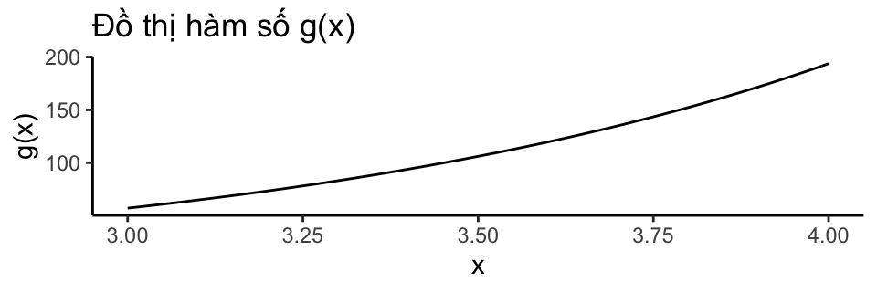

```r
x <- seq( 3 , 4, by = 0.01)
y3 <- (-2)/(derivative2_f(x)) # -2/f'' la f'' la so am (tu cm trong TH nay)
# Vẽ đồ thị
ggplot(data.frame(x, y3), aes(x = x, y = y3)) +
  geom_line() +
  labs(x = "x", y = "g(x)", title = "Đồ thị hàm số g(x)") +
  theme_classic()
```

Dựa vào hình dáng đồ thị thì min $g(x)$ trên đoạn $[3;4]$ là $g(3)$

```r
(-2)/(derivative2_f(3))
```

```
## [1] 56.95927
```

Vậy hệ số $\alpha$ cần chọn chỉ cần thoả $0 < \alpha < g(3)$:

*Code R:*

Chọn $\alpha = 55$:

```r
# Chon x_0 = 3 va alpha =55
fixp0 <- 3
alpha <- 55
# Chay vong lap tim nghiem
for(i in 1:10){
  fixp0 <- fixp0 + alpha * derivative1_f(fixp0)
  print(fixp0)
}
```

```
## [1] 3.806854
## [1] 3.630425
## [1] 3.594769
## [1] 3.591388
## [1] 3.59114
## [1] 3.591123
## [1] 3.591122
## [1] 3.591121
## [1] 3.591121
## [1] 3.591121
```

Chọn $\alpha = 4$:

```r
# Chon x_0 = 3 va alpha =4
fixp1 <- 3
alpha1 <- 4
# Chay vong lap tim nghiem
for(i in 1:40){
  fixp1 <- fixp1 + alpha1 * derivative1_f(fixp1)
  print(fixp1)
}
```

```
## [1] 3.05868
## [1] 3.109419
## [1] 3.153753
## [1] 3.192814
## [1] 3.227468
## [1] 3.258387
## [1] 3.286107
## [1] 3.311062
## [1] 3.333606
## [1] 3.354036
## [1] 3.372601
## [1] 3.38951
## [1] 3.404943
## [1] 3.419057
## [1] 3.431984
```

[output cut: 25 more lines]

Nhược điểm là phụ thuộc vào hệ số $\alpha$ nếu chọn hệ số $\alpha$ không tốt có thể chạy rất nhiêù vòng lặp.

## Bài tập về nhà 1

*The following data are an i.i.d sample from a Cauchy($\theta,1$) distribution: $1.77,-0.23, 2.76, 3.80, 3.47, 56.75, -1.34, 4.24, -2.44, 3.29, 3.71, -2.40, 4.53, -0.07, -1.05, -13.87, -2.53, -1.75, 0.27, 43.21$*

### *Vẽ đồ thị hàm log - likelihood*

Nhập data vào $R$:

```r
data <- c(1.77, -0.23, 2.76, 3.80, 3.47, 56.75, -1.34, 4.24, -2.44, 3.29,
          3.71, -2.40, 4.53, -0.07, -1.05, -13.87, -2.53, -1.75, 0.27, 43.21)
```

*Hàm log - likelihood* cho phân phối Cauchy $\left(\theta, 1\right)$ là:

$$l\left(\theta\right) = \sum_{i=1}^n
\log\left(\dfrac{1}{\pi\left(1+\left(x_i-\theta\right)^2\right)}\right)
= -n\log(\pi) - \sum_{i=1}^n
\log\left(1+\left(x_i-\theta\right)^2\right)$$

Định nghĩa hàm log - likelihood cho phân phối Cauchy trong $R$:

```r
log_likelihoodcauchy <- function(data, theta){
  n <- length(data)
  res <- -n * log(pi) - sum(log(1+(data - theta)^2))
  return(res)
}
```

*Chú ý:*

data (là vector các giá trị số) và đối tượng theta (là một số đơn). Khi bạn thực hiện phép toán data - theta có thể bị sai. (nên sử dụng sapply)

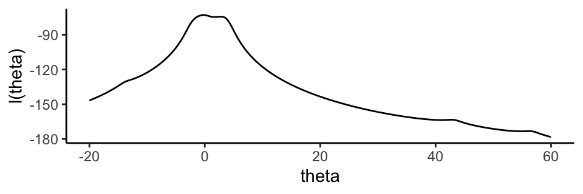

```r
value_theta <- seq(-20, 60, by= 0.1)
log_like <- sapply(value_theta, log_likelihoodcauchy, data = data)
#Có thể dùng for: for(i in 1:length(data)){log_like <- -n * log(pi) - sum(log(1+(data[i]-value_theta)^2)}
# Vẽ đồ thị
par(mfrow=c(1,1))
ggplot(data.frame(value_theta, log_like), aes(x = value_theta, y = log_like)) +
  geom_line() +
  labs(x = "theta", y = "l(theta)") +
  theme_classic()
```

### *Áp dụng thuật toán Newton-Raphson để ước lượng hợp lý cực đại cho $\theta$, với mỗi điểm bắt đầu sau: $-11, -1, 0, 1.5, 4, 4.7, 7, 8$, and 38. Hãy nhận xét kết quả thu được (hội tụ, ổn định). Giá trị trung bình của dữ liệu có phải là điểm khởi đầu tốt không?*

Sử dụng phương pháp Newton - Raphson để tính MLE.

*MLE (Maximum Likelihood Estimation)* hay Ước lượng hợp lý cực đại là một phương pháp thống kê được sử dụng để ước lượng giá trị của các tham số trong một mô hình dựa trên dữ liệu quan sát. Mục tiêu chính của MLE là tìm giá trị của các tham số sao cho xác suất xảy ra của dữ liệu quan sát (gọi là likelihood) là lớn nhất.

Công thức lặp của phương pháp Newton:
$$\theta _{t+1}= \theta_t -
\dfrac{l'(\theta)}{l''(\theta)}$$
Tính $l'(\theta)$:

$$l'(\theta)=\dfrac{\partial
l}{\partial \theta}=2
\sum_{i=1}^{n}\frac{x_i-\theta}{1+\left(x_i-\theta\right)^2}$$
Định nghĩa hàm $l'(\theta)$:

```r
derivative1_l <- function(data,theta){
  n <- length(data)
  res <- 2 * (sum((data - theta )/(1 + (data - theta)^2)))
  return(res)
}
```

Tính $l''(\theta)$:

$$l''(\theta)= \sum_{i=1}^n
\dfrac{-2 -6\left(x_i - \theta\right)^2}{\left(1+\left(x_i - \theta
\right)^2\right)^2}$$
Định nghĩa hàm $l''(\theta)$:

```r
derivative2_l <- function(data, theta){
  n <- length(data)
  res <- sum((-2 - 6 * (data - theta)^2) / ((1 + (data - theta)^2)^2))
  return(res)
}
```

Vòng lặp của Newton - Raphson:

```r
newton_r <- function(data, theta_start, tol = 1e-6, max_iter = 100) {
  theta_value <- numeric(max_iter) # Tạo vector để lưu giá trị theta
  theta <- theta_start

  for (i in 1:max_iter) {
    theta_new <- theta - (derivative1_l(data, theta)) / (derivative2_l(data, theta))
    theta_value[i] <- theta_new # Lưu giá trị mới của theta

    # Kiểm tra điều kiện dừng
    if (i > 1 && abs(theta_new - theta) < tol) {
      #cat("Hội tụ tại vòng lặp", i, "với giá trị theta =", theta_new, "\n")
      return(theta_value[1:i]) # Trả về các giá trị theta đã lưu đến khi hội tụ
    }

    # Cập nhật theta cho lần lặp tiếp theo
    theta <- theta_new
  }

  cat("Không hội tụ sau", max_iter, "vòng lặp.\n")
  return(theta_value)
}
```

Điểm bắt đầu:

```r
startpoint <- c(-11, 1, 0, 1.5, 4, 4.7, 7, 8, 38)
```

```r
# Định nghĩa số vòng lặp tối đa
max_iter <- 100

# Tạo bảng để lưu kết quả
results_df <- data.frame(matrix(nrow = max_iter, ncol = length(startpoint)))
colnames(results_df) <- paste("Start:", startpoint)

# Tính Newton-Raphson cho từng điểm khởi đầu và lưu vào bảng
for (i in seq_along(startpoint)) {
  result <- newton_r(data, startpoint[i], tol = 1e-6, max_iter = max_iter)
  results_df[1:length(result), i] <- result # Lưu các giá trị tính được
}

# In bảng kết quả
print(results_df)
```

```
##     Start: -11    Start: 1    Start: 0  Start: 1.5 Start: 4 Start: 4.7 Start: 7
## 1   -9.3034188  0.93467498 -0.03434521  1.48573495 3.629590   4.067696 5.571991
## 2   -7.0906286  0.86281776 -0.06251555  1.47030582 3.408030   3.670474 4.679478
## 3   -5.1128351  0.78446913 -0.08558613  1.45358699 3.270885   3.432466 4.053654
## 4   -3.7403337  0.70015615 -0.10447881  1.43543514 3.178504   3.286620 3.661990
## 5   -2.8524985  0.61107529 -0.11996110  1.41568633 3.111883   3.189485 3.427405
## 6   -2.2138742  0.51921873 -0.13266226  1.39415264 3.061534   3.119997 3.283376
## 7   -1.8360440  0.42733648 -0.14309436  1.37061829 3.022219   3.067769 3.187230
## 8   -1.5823580  0.33862673 -0.15167298  1.34483541 2.990787   3.027145 3.118335
## 9   -1.3838084  0.25615705 -0.15873527  1.31651935 2.965207   2.994759 3.066494
## 10  -1.2227251  0.18222716 -0.16455507  1.28534407 2.944104   2.968462 3.026139
## 11  -1.0897640  0.11799255 -0.16935520  1.25093787 2.926505   2.946804 2.993949
## 12  -0.9779015  0.06350404 -0.17331735  1.21288067 2.911700   2.928766 2.967799
## 13  -0.8817872  0.01803858 -0.17658994  1.17070421 2.899155   2.913608 2.946254
## 14  -0.7976232 -0.01951406 -0.17929448  1.12389813 2.888463   2.900776 2.928305
```

[output cut: 187 more lines]

```r
# In hàng cuối cùng của kết quả hợp lệ (bỏ qua NA)
last_iteration <- apply(results_df, 2, function(col) tail(col[!is.na(col)], 1))
print(last_iteration)
```

```
## Start: -11   Start: 1   Start: 0 Start: 1.5   Start: 4 Start: 4.7   Start: 7
## -0.1922913 -0.1922822 -0.1922826 -0.1922820  2.8174795  2.8174797  2.8174797
##   Start: 8  Start: 38
##  2.8174792  2.8174795
```

*Từ bảng kết quả cho thấy các điểm startpoint khác nhau sẽ cho ra kết quả khác nhau.*

Tính thử hàm trên với điểm bắt đầu là Mean của dữ liệu:

```r
mean_data <- mean(data)
# Gọi hàm newton_r
theta_result1 <- newton_r(data, mean_data, tol= 1e-6, 100)
# In ra giá trị của theta tại vòng lặp thứ 100
print(theta_result1)
```

```
##  [1] 4.356937 3.845844 3.536942 3.351956 3.233994 3.152344 3.092342 3.046403
##  [9] 3.010197 2.981049 2.957204 2.937450 2.920921 2.906977 2.895137 2.885026
## [17] 2.876352 2.868882 2.862427 2.856832 2.851973 2.847742 2.844053 2.840830
## [25] 2.838010 2.835541 2.833377 2.831478 2.829810 2.828344 2.827055 2.825921
## [33] 2.824923 2.824044 2.823270 2.822587 2.821986 2.821456 2.820988 2.820576
## [41] 2.820212 2.819891 2.819608 2.819358 2.819137 2.818942 2.818770 2.818619
## [49] 2.818485 2.818366 2.818262 2.818169 2.818088 2.818016 2.817953 2.817896
## [57] 2.817847 2.817803 2.817765 2.817730 2.817700 2.817674 2.817650 2.817629
## [65] 2.817611 2.817595 2.817580 2.817568 2.817557 2.817547 2.817538 2.817530
## [73] 2.817524 2.817518 2.817512 2.817508 2.817503 2.817500 2.817497 2.817494
## [81] 2.817491 2.817489 2.817487 2.817485 2.817484 2.817482 2.817481 2.817480
## [89] 2.817479
```

### *Áp dụng phương pháp bisection với điểm bắt đầu là [-1;1]. Sử dụng các lần chạy bổ sung để minh hoạ cách thức mà phương pháp Bisection có thể tìm được giá trị cực đại toàn cục*

Code R:

Kiểm tra $l'(-1) \times l'(1)$:

```r
derivative1_l(data,-1) * derivative1_l(data, 1)
```

```
## [1] -2.130386
```

Ở đây ta sử dụng công thức lặp nghiệm $a_{t+1}= \dfrac{a_t+b_t}{2}$:

$$a_{t+1}=a_t+\dfrac{b_t-a_t}{2}$$

```r
bisec0 <- -1
bisec1 <- 1
bisec <- (bisec1 + bisec0)/2
tolerance <- 1e-6  #Điều kiện sai số _ dừng thuật toán

#vong lap
iter <- 100
for(i in 1:iter){

  #Giá trị điều kiện
  cond1 <- derivative1_l(data,bisec0) * derivative1_l(data,bisec)

  if (cond1 > 0) {
    bisec0 <- bisec
  } else {
    bisec1 <- bisec
  }

  bisec <- (bisec1 + bisec0)/2

  cat("Lần lặp", i, ": x = ", format(bisec, nsmall = 6), "\n")

  #Điệu kiện dừng
  if (abs(bisec1 - bisec0) < tolerance){cat("Thuật toán dừng lại tại lần lặp thứ", i , "với nghiệm x =", format(bisec, nsmall = 6),"\n")
  break}

}
```

```
## Lần lặp 1 : x =  -0.500000
## Lần lặp 2 : x =  -0.250000
## Lần lặp 3 : x =  -0.125000
## Lần lặp 4 : x =  -0.187500
## Lần lặp 5 : x =  -0.218750
## Lần lặp 6 : x =  -0.203125
## Lần lặp 7 : x =  -0.1953125
## Lần lặp 8 : x =  -0.1914062
## Lần lặp 9 : x =  -0.1933594
## Lần lặp 10 : x =  -0.1923828
## Lần lặp 11 : x =  -0.1918945
## Lần lặp 12 : x =  -0.1921387
## Lần lặp 13 : x =  -0.1922607
## Lần lặp 14 : x =  -0.1923218
## Lần lặp 15 : x =  -0.1922913
## Lần lặp 16 : x =  -0.192276
## Lần lặp 17 : x =  -0.1922836
## Lần lặp 18 : x =  -0.1922874
## Lần lặp 19 : x =  -0.1922855
## Lần lặp 20 : x =  -0.1922865
## Lần lặp 21 : x =  -0.192287
## Thuật toán dừng lại tại lần lặp thứ 21 với nghiệm x = -0.192287
```

### *Từ các giá trị khởi đầu của $\left(\theta^{(0)},\theta^{(1)}\right)=(-2,1)$, áp dụng phương pháp Secant để tìm ước lượng hợp lý cực đại cho $\theta$. Điều này xảy ra khi $\left(\theta^{(0)},\theta^{(1)}\right)=(-3,3)$, và đối với các lựa chọn khởi đầu khác*

Sử dụng công thức lặp nghiệm của *phương pháp Secant*:
$$x_{t+1}=x_t-f'(x_t)\times
\dfrac{x_t-x_{t-1}}{f'(x_t)-f'(x_{t-1})}$$
Code R:

*Trường hợp 1: $\left(\theta^{(0)},\theta^{(1)}\right)=(-2,1)$*

```r
theta0 <- -2
theta1 <- 1

tolerance <- 1e-6  #Điều kiện sai số _ dừng thuật toán

#vong lap
iter <- 100
for(i in 1:iter){

  theta_prev <- theta1 #Lưu theta1 vào biến theta_prev để kiểm tra điều kiện dừng thuật toán

  theta1 <- theta1 - derivative1_l(data, theta1) * ((theta1 - theta0) / (derivative1_l(data, theta1) - derivative1_l(data, theta0)))

  cat("Lần lặp", i, ": x = ", format(theta1, nsmall = 6), "\n")

  #Điệu kiện dừng
  if (abs(theta1 - theta_prev) < tolerance){cat("Thuật toán dừng lại tại lần lặp thứ", i , "với nghiệm x =", format(theta1, nsmall = 6),"\n")
  break}

}
```

```
## Lần lặp 1 : x =  0.4857874
## Lần lặp 2 : x =  -0.07771932
## Lần lặp 3 : x =  -0.1983821
## Lần lặp 4 : x =  -0.1920558
## Lần lặp 5 : x =  -0.1922957
## Lần lặp 6 : x =  -0.1922863
## Lần lặp 7 : x =  -0.1922866
## Thuật toán dừng lại tại lần lặp thứ 7 với nghiệm x = -0.1922866
```

*Trường hợp 2: $\left(\theta^{(0)},\theta^{(1)}\right)=(-3,3)$*

```r
theta2 <- -3
theta3 <- 3

tolerance <- 1e-6  #Điều kiện sai số _ dừng thuật toán

#vong lap
iter <- 100
for(i in 1:iter){

  theta_prev <- theta3 #Lưu theta1 vào biến theta_prev để kiểm tra điều kiện dừng thuật toán

  theta3 <- theta3 - derivative1_l(data, theta3) * ((theta3 - theta2) / (derivative1_l(data, theta3) - derivative1_l(data, theta2)))

  cat("Lần lặp", i, ": x = ", format(theta3, nsmall = 6), "\n")

  #Điệu kiện dừng
  if (abs(theta3 - theta_prev) < tolerance){cat("Thuật toán dừng lại tại lần lặp thứ", i , "với nghiệm x =", format(theta3, nsmall = 6),"\n")
  break}

}
```

```
## Lần lặp 1 : x =  2.685789
## Lần lặp 2 : x =  2.831297
## Lần lặp 3 : x =  2.812017
## Lần lặp 4 : x =  2.819416
## Lần lặp 5 : x =  2.816751
## Lần lặp 6 : x =  2.817736
## Lần lặp 7 : x =  2.817375
## Lần lặp 8 : x =  2.817508
## Lần lặp 9 : x =  2.817459
## Lần lặp 10 : x =  2.817477
## Lần lặp 11 : x =  2.817470
## Lần lặp 12 : x =  2.817473
## Lần lặp 13 : x =  2.817472
## Thuật toán dừng lại tại lần lặp thứ 13 với nghiệm x = 2.817472
```

### Sử dụng ví dụ này để so sánh tốc độ và tính ổn định của phương pháp Newton-Raphson, bisection, fixed-point và phương pháp secant. Kết luân của bạn có thay đổi khi bạn áp dụng các phương pháp này cho một ngẫu nhiên có kích thước 20 từ phân phối chuẩn $\left(\theta,1\right)$ không?

Code R cho phương pháp Fixed-point với hệ số $x_0=3, \alpha =4$:

```r
# Chon x_0 = 3 va alpha =4
fixp1 <- 3
alpha1 <- 4
tolerance <- 1e-6
# Chay vong lap tim nghiem
iter <- 40
for(i in 1:iter){
  fixp1_prev <- fixp1
  fixp1 <- fixp1 + alpha1 * derivative1_l(data,fixp1)
  cat("Lần lặp", i, ": x = ", format(fixp1, nsmall = 6), "\n")

  #Điệu kiện dừng
  if (abs(fixp1 - fixp1_prev) < tolerance){cat("Thuật toán dừng lại tại lần lặp thứ", i , "với nghiệm x =", format(fixp1, nsmall = 6),"\n")
  break}
}
```

```
## Lần lặp 1 : x =  0.9348109
## Lần lặp 2 : x =  -3.964014
## Lần lặp 3 : x =  29.012619
## Lần lặp 4 : x =  24.796217
## Lần lặp 5 : x =  19.516359
## Lần lặp 6 : x =  12.389685
## Lần lặp 7 : x =  0.1373986
## Lần lặp 8 : x =  -3.847321
## Lần lặp 9 : x =  30.022088
## Lần lặp 10 : x =  26.034850
## Lần lặp 11 : x =  21.091714
## Lần lặp 12 : x =  14.607133
## Lần lặp 13 : x =  4.546946
## Lần lặp 14 : x =  -31.861703
## Lần lặp 15 : x =  -27.054851
## Lần lặp 16 : x =  -21.350937
## Lần lặp 17 : x =  -13.906531
## Lần lặp 18 : x =  -3.973628
## Lần lặp 19 : x =  28.929371
## Lần lặp 20 : x =  24.693797
## Lần lặp 21 : x =  19.384908
## Lần lặp 22 : x =  12.199958
## Lần lặp 23 : x =  -0.283583
## Lần lặp 24 : x =  0.8103525
## Lần lặp 25 : x =  -4.851572
## Lần lặp 26 : x =  21.953509
## Lần lặp 27 : x =  15.782229
## Lần lặp 28 : x =  6.604122
## Lần lặp 29 : x =  -21.604311
## Lần lặp 30 : x =  -14.264788
## Lần lặp 31 : x =  -2.124477
## Lần lặp 32 : x =  21.539685
## Lần lặp 33 : x =  15.220937
## Lần lặp 34 : x =  5.640346
## Lần lặp 35 : x =  -29.522199
## Lần lặp 36 : x =  -24.320124
## Lần lặp 37 : x =  -17.914985
## Lần lặp 38 : x =  -8.490068
## Lần lặp 39 : x =  5.679335
## Lần lặp 40 : x =  -29.184906
```

$\Rightarrow$ Phương pháp Fixed-point không hiệu quả trong trường hợp này:

- Việc xác định hệ số $\alpha$ đối với các hàm phức tạp khá khó khăn.

So sánh tốc độ của các phương pháp còn lại:

```r
# Newton-Raphson
start_time_newton <- Sys.time()
newton_result <- newton_r(data, startpoint[1], tol = 1e-6, max_iter = 100)
end_time_newton <- Sys.time()
time_taken_newton <- end_time_newton - start_time_newton

# Bisection
start_time_bisec <- Sys.time()
bisec0 <- -1
bisec1 <- 1
bisec <- (bisec1 + bisec0) / 2
tolerance <- 1e-6
iter <- 100
for(i in 1:iter){
  cond1 <- derivative1_l(data, bisec0) * derivative1_l(data, bisec)
  if (cond1 > 0) {
    bisec0 <- bisec
  } else {
    bisec1 <- bisec
  }
  bisec <- (bisec1 + bisec0) / 2
  if (abs(bisec1 - bisec0) < tolerance) {
    break
  }
}
end_time_bisec <- Sys.time()
time_taken_bisec <- end_time_bisec - start_time_bisec

# Secant
start_time_secant <- Sys.time()
theta0 <- -2
theta1 <- 1
iter <- 100
for(i in 1:iter){
  theta_prev <- theta1
  theta1 <- theta1 - derivative1_l(data, theta1) * ((theta1 - theta0) / (derivative1_l(data, theta1) - derivative1_l(data, theta0)))
  if (abs(theta1 - theta_prev) < tolerance) {
    break
  }
}
end_time_secant <- Sys.time()
time_taken_secant <- end_time_secant - start_time_secant

# In kết quả
cat("Thời gian thực thi Newton-Raphson:", time_taken_newton, "\n")
```

```
## Thời gian thực thi Newton-Raphson: 0.001906157
```

```r
cat("Thời gian thực thi Bisection:", time_taken_bisec, "\n")
```

```
## Thời gian thực thi Bisection: 0.01114297
```

```r
cat("Thời gian thực thi Secant:", time_taken_secant, "\n")
```

```
## Thời gian thực thi Secant: 0.0077281
```

*So sánh các phương pháp:*

- *Newton-Raphson:*

Ưu điểm: Nhanh nếu đạo hàm đủ chính xác.

Nhược điểm: Nhạy cảm với giá trị khởi đầu và đạo hàm bậc hai.

- *Bisection:*

Ưu điểm: Ổn định nhưng chậm.

Nhược điểm: Yêu cầu tìm khoảng ban đầu $[a,b]$.

- *Secant:*

Ưu điểm: Không yêu cầu đạo hàm bậc hai.

Nhược điểm: Kém ổn định hơn Newton-Raphson.

- *Fixed-point:*

Chậm hơn và kém ổn định trên các hàm phi tuyến tính.